# Robótica Probabilística

Estimação de Estado Recursiva

Prof. Dr. Fagner de Assis Moura Pimentel

# Estimação de Estado Recursiva

Capítulo 2 do livro [**Probabilistic Robotics**](http://probabilistic-robotics.informatik.uni-freiburg.de/), de **Sebastian Thrun**, **Wolfram Burgard** e **Dieter Fox**.

[figure not shown]

## Estimação de Estado:

### Núcleo da Robótica Probabilística

- Ideia central da robótica probabilística: **estimar o estado a partir de dados de sensores**
- **Estimação de estado**: aborda o problema de estimar grandezas não diretamente observáveis, mas que podem ser inferidas a partir de dados de sensores
- Em muitas aplicações robóticas, decidir o que fazer é relativamente simples se certas grandezas forem conhecidas
  - Ex: mover um robô móvel é relativamente fácil se a localização exata do robô e dos obstáculos próximos forem conhecidas

[figure not shown]

## Estimação de Estado: o Problema

- Essas variáveis não são diretamente mensuráveis
- O robô precisa confiar em seus sensores para coletar essa informação
- Sensores carregam apenas informação parcial sobre essas grandezas, e suas medições são corrompidas por ruído
- Estimação de estado busca recuperar as variáveis de estado a partir dos dados
- Algoritmos probabilísticos de estimação de estado calculam **distribuições de crença** (*belief distributions*) sobre os possíveis estados do mundo

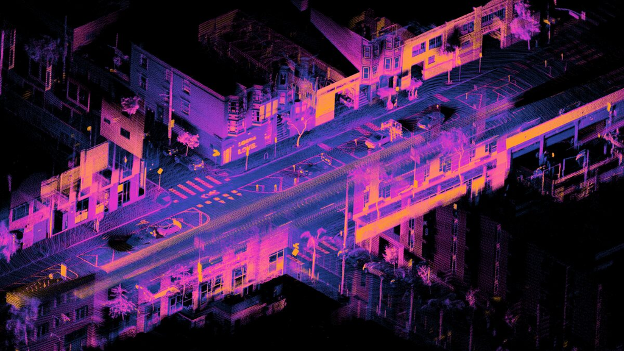

Nuvem de pontos de LiDAR — D. L. Lu, CC BY 4.0

## Interação Entre Robô e Ambiente

- Ambiente (ou mundo) de um robô: sistema dinâmico que possui estado interno
- O robô adquire informação sobre o ambiente por meio de seus **sensores**
  - Limitações: são ruidosos; muitas grandezas não podem ser sensoriadas diretamente
  - Consequência: o robô mantém uma **crença interna** (*belief*) sobre o estado do ambiente
- O robô também pode influenciar seu ambiente por meio de **atuadores**
  - O efeito de agir sobre o ambiente é frequentemente algo imprevisível

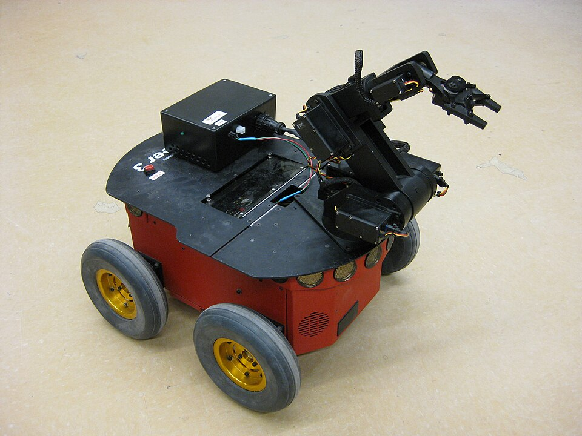

Pioneer 3-AT — J. Wang, CC BY-SA 3.0

## Estado (State)

- Ambientes são caracterizados por **estado**: conjunto de todos os aspectos do robô e de seu ambiente que podem impactar o futuro

**Tipos de Estado**

- Estado dinâmico: muda ao longo do tempo (ex: localização de pessoas)
- Estado estático: não muda (ex: localização de paredes na maioria dos edifícios)
- Também incluídas: pose, velocidade, se os sensores estão funcionando corretamente, entre outras

[figure not shown]

## Estado: Notação

- O estado é um **vetor** $x$; quais variáveis entram em $x$ depende do contexto
- Estado no instante $t$: denotado $x_t$
- **Exemplo** — robô móvel num plano: o estado é a sua **pose** $x_t = \langle x,\ y,\ \theta \rangle$ (posição e orientação)

[figure not shown]

## Variáveis de Estado Típicas em Robótica

1. **Pose do Robô** (*kinematic state*) — localização e orientação em relação a um referencial global
   - Robôs móveis: 6 variáveis (3 coordenadas + 3 orientações angulares — *pitch, roll, yaw*)
   - Robôs em ambientes planos: geralmente 3 variáveis (2 de localização + *heading*/*yaw*)
2. **Velocidade do Robô e de suas Articulações** (*dynamic state*) — até 6 variáveis de velocidade

[figure not shown]

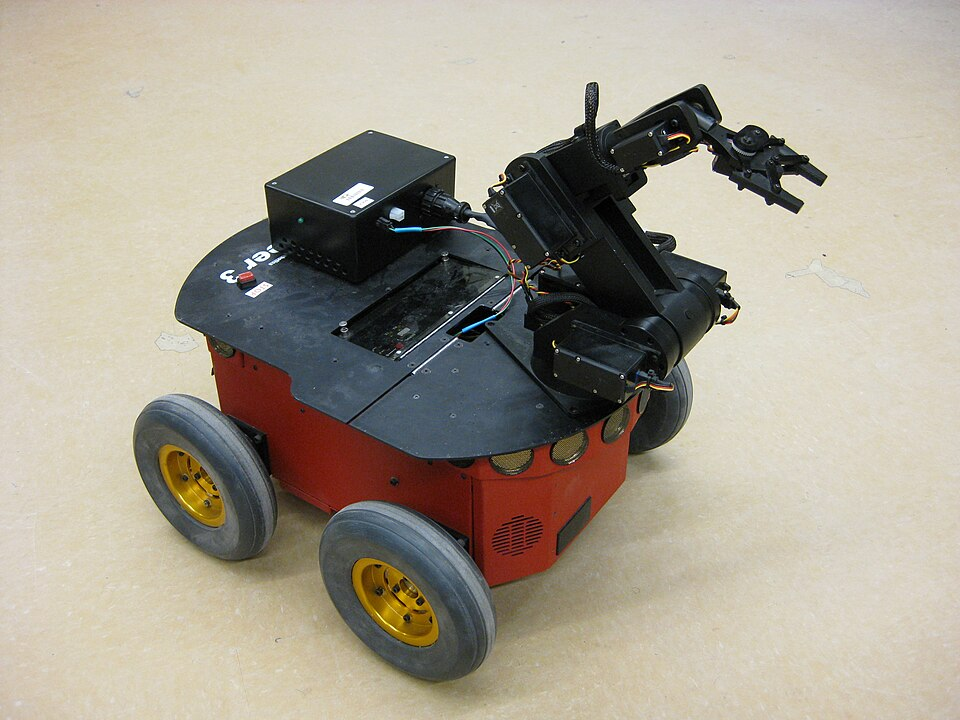

Pioneer 3-AT — J. Wang, CC BY-SA 3.0

## Variáveis de Estado Típicas em Robótica

4. **Localização e Características de Objetos no Ambiente** — árvores, paredes; podem assumir a forma de marcos (*landmarks*); o número de variáveis varia de poucas dezenas a centenas de bilhões, conforme a granularidade do modelo

[figure not shown]

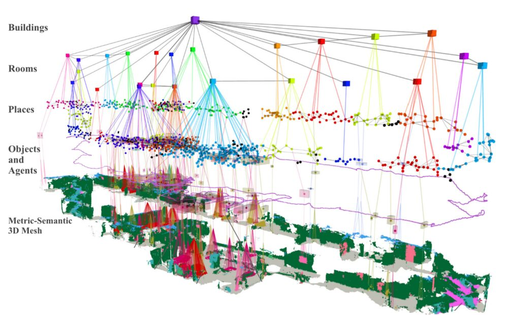

Mapa semântico construído por robô — F. Fernando, CC BY 4.0

5. **Localização e Velocidades de Objetos e Pessoas em Movimento** — o robô raramente é o único ator em movimento no ambiente

[figure not shown]

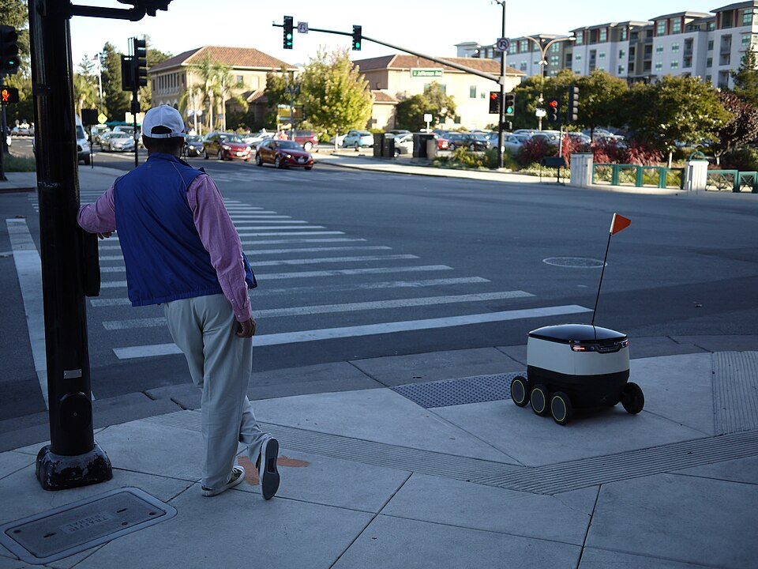

Robô e pedestre, Redwood City — C. Down, CC BY 4.0

## Variáveis de Estado Típicas em Robótica

[figure not shown]

[figure not shown]

Braço UR16e — Auledas, CC BY-SA 4.0

6. **Outras Variáveis** — ex: sensor quebrado, nível de bateria

[figure not shown]

## Completude do Estado (State Completeness)

- Um estado $x_t$ é **completo** se for o melhor preditor do futuro
- Completude significa: conhecimento de estados, medições ou controles passados não carrega informação adicional que ajude a prever o futuro com mais precisão que o estado atual
- Completude **não** exige que o futuro seja função determinística do estado
  - O futuro pode ser estocástico, mas nenhuma variável anterior a $x_t$ pode influenciar a evolução estocástica dos estados futuros, a menos que essa dependência seja mediada pelo próprio $x_t$
- Processos temporais que atendem a essas condições são conhecidos como **Cadeias de Markov** (*Markov chains*)

[figure not shown]

## Importância Prática: Estado Incompleto

- A noção de completude de estado é principalmente de importância teórica
- Na prática, é impossível especificar um estado completo para qualquer sistema robótico realista
  - Incluiria não só o ambiente, mas também o próprio robô, o conteúdo de sua memória computacional, “estados mentais” das pessoas ao redor etc. — difíceis (ou impossíveis) de obter
- Implementações práticas selecionam um pequeno subconjunto das variáveis de estado
- Tal estado é chamado de **estado incompleto**

[figure not shown]

## Tempo

- Na maioria dos problemas interessantes de robótica, o estado muda ao longo do tempo
- Em robótica probabilística, o tempo é tratado como **discreto** — eventos ocorrem em passos: $0, 1, 2, \dots$
- Se o robô inicia sua operação em um ponto distinto no tempo, esse instante será denotado $t = 0$

[figure not shown]

## Interação Robô-Ambiente

Existem dois tipos fundamentais de interação entre robô e ambiente:

- Influenciar o estado do ambiente por meio de **atuadores**
- Coletar informação sobre o estado por meio de **sensores**

Ambos podem ocorrer simultaneamente, mas por razões didáticas serão distinguidos nesta disciplina.

[figure not shown]

## Dados: Medições e Controle

- O robô pode manter registro de todas as medições e ações de controle passadas — coletivamente chamado de **dados** (*data*)
- Existem duas correntes de dados diferentes, correspondendo aos dois tipos de interação:
  - Dados de Medição (*Measurement Data*)
  - Dados de Controle (*Control Data*)

[figure not shown]

## Dados de Medição (Measurement Data)

- Fornecem informação sobre o estado momentâneo do ambiente
  - Exemplos: imagens de câmera, varreduras de alcance
  - Efeitos de timing pequenos geralmente ignorados (ex: lidar escaneia sequencialmente, mas assume-se instante único)
- Assume-se exatamente uma medição por vez

**Notação**: $z_t$ (medição no instante $t$)

Sequência de medições:
$$z_{t_1:t_2} = z_{t_1}, z_{t_1+1}, \dots, z_{t_2} \qquad (t_1 \le t_2)$$

[figure not shown]

Sensor LiDAR Velodyne — S. Jurvetson, CC BY 2.0

## Dados de Controle (Control Data)

- Carregam informação sobre a mudança de estado no ambiente
- Exemplo típico: velocidade do robô (ex: 10 cm/s por 5s → pose avança ~50 cm)
- Fonte alternativa: odômetros (sensores que medem a revolução das rodas) — tratados como dado de controle, pois a informação principal refere-se à mudança de estado

**Notação**: $u_t$ (mudança de estado no intervalo $(t-1, t]$)

Sequência de controles:
$$u_{t_1:t_2} = u_{t_1}, u_{t_1+1}, \dots, u_{t_2} \qquad (t_1 \le t_2)$$

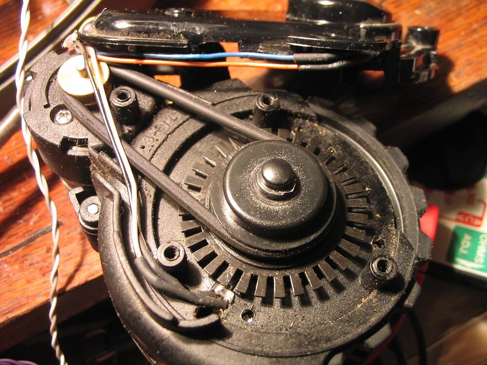

Encoder na roda de um Roomba — A. Mayer, CC BY-SA 2.0

A passagem do tempo, mesmo sem ação, constitui tecnicamente informação de controle. Assume-se um item de controle por passo de tempo.

## Distinção entre Medição e Controle

- Os dois tipos de dados desempenham papéis fundamentalmente diferentes
- **Percepção**: fornece informação sobre o estado → tende a **aumentar** o conhecimento do robô
- **Movimento**: tende a induzir **perda** de conhecimento, devido ao ruído da atuação e à estocasticidade do ambiente (às vezes um controle pode tornar o robô mais certo)
- Essa distinção não implica que ações e percepções ocorrem em momentos separados — na prática ocorrem concorrentemente (muitos sensores afetam o próprio ambiente); a separação é feita por conveniência didática

[figure not shown]

# Leis Generativas Probabilísticas

As duas distribuições que definem o sistema dinâmico do robô e seu ambiente: como o estado evolui sob a ação de controle e como as medições são geradas a partir do estado.

## As Duas Probabilidades Fundamentais

**Probabilidade de transição de estado**: $p(x_t \mid x_{t-1}, u_t)$

- Especifica como o estado ambiental evolui em função dos controles do robô
- Ambientes robóticos são estocásticos: é uma distribuição de probabilidade, não uma função determinística

**Probabilidade de medição**: $p(z_t \mid x_t)$

- Especifica a lei segundo a qual as medições $z$ são geradas a partir do estado $x$
- Medições geralmente são projeções ruidosas do estado

[figure not shown]

## Modelo Generativo Temporal

- Probabilidade de transição + probabilidade de medição descrevem juntas o sistema dinâmico estocástico do robô e seu ambiente
- Esse modelo é conhecido como **Modelo Oculto de Markov** (*HMM*) ou **Rede Bayesiana Dinâmica** (*DBN*)
- Para especificar o modelo completamente, também é necessária a distribuição de estado inicial $p(x_0)$

[figure not shown]

# Distribuições de Crença

O conhecimento interno do robô sobre o estado — uma distribuição de probabilidade sobre todas as hipóteses possíveis, já que o estado real nunca é observado diretamente.

## Distribuições de Crença (Belief Distributions)

- Conceito-chave em robótica probabilística: **crença** (*belief*)
- Reflete o conhecimento interno do robô sobre o estado do ambiente
- O estado não pode ser medido diretamente
  - Ex: pose do robô $x = \langle 14{,}12,\ 12{,}7,\ 0{,}755 \rangle$ — mas o robô geralmente não pode conhecer sua pose exata (nem mesmo com GPS!)
  - O robô precisa **inferir** sua pose a partir de dados
- Distinção importante: **estado verdadeiro** vs. **crença interna**

[figure not shown]

## Representação Matemática

- A robótica probabilística representa crenças por meio de distribuições de probabilidade condicionais
- Distribuição de crença: atribui uma probabilidade (ou densidade) a cada hipótese possível sobre o estado verdadeiro

[figure not shown]

## Notação

Crença sobre a variável de estado $x_t$: $bel(x_t)$, abreviação de:
$$bel(x_t) = p(x_t \mid z_{1:t}, u_{1:t})$$

Distribuição de probabilidade sobre o estado $x_t$ no instante $t$, condicionada a todas as medições passadas ($z_{1:t}$) e controles passados ($u_{1:t}$). Calculada **após** incorporar a medição $z_t$.

## Predição (Prediction)

Às vezes é útil calcular uma posterior antes de incorporar $z_t$, logo após executar o controle $u_t$:
$$\overline{bel}(x_t) = p(x_t \mid z_{1:t-1}, u_{1:t})$$

- Chamada de **predição**, no contexto de filtragem probabilística
- Reflete que $\overline{bel}(x_t)$ prediz o estado em $t$ com base na posterior do estado anterior, antes de incorporar a medição
- Calcular $bel(x_t)$ a partir de $\overline{bel}(x_t)$ é chamado de **correção** ou **atualização de medição** (*measurement update*)

[figure not shown]

# Filtro de Bayes

O algoritmo recursivo geral para atualizar a crença a cada novo par (controle, medição). Todos os filtros usados na robótica probabilística derivam dele.

## Algoritmo do Filtro de Bayes

- Algoritmo mais geral para calcular crenças: **Filtro de Bayes** (*Bayes filter*)
- Calcula a distribuição de crença $bel$ a partir de dados de medição e controle
- **Recursivo**: $bel(x_t)$ é calculada a partir de $bel(x_{t-1})$
- **Entrada**: crença $bel$ em $t-1$, controle mais recente $u_t$, medição mais recente $z_t$
- **Saída**: crença $bel(x_t)$ no instante $t$

$$\begin{array}{l}
\hline
\textbf{Filtro de Bayes}\;\bigl(bel(x_{t-1}),\ u_t,\ z_t\bigr) \\
\hline
\text{1:}\quad \textbf{para todo } x_t \textbf{ faça} \\
\text{2:}\qquad \overline{bel}(x_t) = \int p(x_t \mid u_t, x_{t-1})\, bel(x_{t-1})\, dx \\
\text{3:}\qquad bel(x_t) = \eta \, p(z_t \mid x_t)\, \overline{bel}(x_t) \\
\text{4:}\quad \textbf{fim para} \\
\text{5:}\quad \textbf{retornar } bel(x_t) \\
\hline
\end{array}$$

## Passos Essenciais

**1. Processamento do Controle** (*Control Update* / Predição): calcula $\overline{bel}(x_t)$ a partir da crença anterior $bel(x_{t-1})$ e do controle $u_t$

**2. Atualização de Medição** (*Measurement Update*): multiplica $\overline{bel}(x_t)$ pela probabilidade de $z_t$ e normaliza pela constante $\eta$, produzindo $bel(x_t)$

[figure not shown]

## Crença Inicial

- Para calcular a posterior recursivamente, o algoritmo exige uma crença inicial $bel(x_0)$ em $t=0$
- Conhecimento parcial de $x_0$ também pode ser expresso por distribuições não uniformes
- Na prática, os casos mais comuns são: conhecimento total ou ignorância total

[figure not shown]

## Limitações Práticas

- O algoritmo, na forma apresentada, só pode ser implementado diretamente para problemas de estimação muito simples
- Requisitos:
  - Capacidade de realizar a integração (predição) e a multiplicação (atualização) em forma fechada, **ou**
  - Restringir-se a espaços de estado finitos, tornando a integral uma soma finita

## Exemplo

Um robô móvel estimando o estado de uma **porta** (aberta ou fechada): ele **percebe** a porta com um sensor e pode **empurrá-la**.

[figure not shown]

percepção — mede o estado da porta

[figure not shown]

ação — empurra a porta

## Cenário

- Robô estima o estado de uma porta usando câmera
- Estados possíveis: **aberta** ou **fechada**
- Apenas o robô pode mudar o estado da porta
- Crença inicial (desconhecimento total):

$$bel(X_0 = \text{aberta}) = 0{,}5 \qquad bel(X_0 = \text{fechada}) = 0{,}5$$

## Modelo de Medição (Sensor Ruidoso)

$$\begin{aligned}
p(\text{percebe aberta} \mid \text{está aberta}) &= 0{,}6 \\
p(\text{percebe fechada} \mid \text{está aberta}) &= 0{,}4 \\
p(\text{percebe aberta} \mid \text{está fechada}) &= 0{,}2 \\
p(\text{percebe fechada} \mid \text{está fechada}) &= 0{,}8
\end{aligned}$$

Sensor é relativamente confiável para detectar porta fechada (erro de 0,2); menos confiável para porta aberta (erro de 0,4).

[figure not shown]

## Modelo de Transição de Estado (Ação de Controle)

- Ação **“empurrar”** (*push*): se já aberta, permanece aberta (prob. 1,0); se fechada, 0,8 de chance de abrir
- Ação **“não fazer nada”**: estado do mundo não muda (probabilidade 1,0 de permanecer no mesmo estado), esteja aberta ou fechada

[figure not shown]

## Passo 1

$t=1$, controle = não fazer nada, medição = percebe aberta

**Predição**

- $\overline{bel}(X_1{=}\text{aberta}) = 1{,}0 \cdot 0{,}5 = 0{,}5$
- $\overline{bel}(X_1{=}\text{fechada}) = 1{,}0 \cdot 0{,}5 = 0{,}5$

**Correção**

- $bel(X_1{=}\text{aberta}) = \eta \cdot 0{,}6 \cdot 0{,}5 = \eta \cdot 0{,}3$
- $bel(X_1{=}\text{fechada}) = \eta \cdot 0{,}2 \cdot 0{,}5 = \eta \cdot 0{,}1$
- Normalizador: $\eta = (0{,}3+0{,}1)^{-1} = 2{,}5$

[figure not shown]

## Passo 2

$t=2$, controle = empurrar, medição = percebe aberta

**Predição** (ação “empurrar”)

- $\overline{bel}(X_2{=}\text{aberta}) = 1 \cdot 0{,}75 + 0{,}8 \cdot 0{,}25 = 0{,}95$
- $\overline{bel}(X_2{=}\text{fechada}) = 0 \cdot 0{,}75 + 0{,}2 \cdot 0{,}25 = 0{,}05$

**Correção** (mede “aberta”)

- $bel(X_2{=}\text{aberta}) = \eta \cdot 0{,}6 \cdot 0{,}95 \approx 0{,}983$
- $bel(X_2{=}\text{fechada}) = \eta \cdot 0{,}2 \cdot 0{,}05 \approx 0{,}017$

[figure not shown]

## Interpretação Final

- Após duas iterações, o robô acredita com **98,3%** de probabilidade que a porta está aberta
- Apesar de parecer alta o suficiente para aceitar como certa, essa abordagem pode gerar custos desnecessariamente altos
- Se confundir porta fechada com aberta tem custo alto (ex: colisão), é essencial considerar ambas as hipóteses no processo de decisão, por mais improvável que uma pareça
- Analogia: imagine pilotar um avião no piloto automático com 98,3% de chance percebida de não colidir!

[figure not shown]

# Representação e Computação

Como levar o filtro de Bayes à prática: formas de aproximar a distribuição de crença e os compromissos entre eficiência computacional, precisão e facilidade de implementação.

## Representação e Computação

- Filtros de Bayes são implementados de diversas formas na robótica probabilística
- Existe grande variedade de técnicas e algoritmos, todos derivados do filtro de Bayes
- Cada técnica baseia-se em diferentes suposições sobre medição, transição de estado e crença inicial
- Essas suposições geram diferentes tipos de distribuições posteriores, com algoritmos de características computacionais distintas

[figure not shown]

## Necessidade de Aproximação

- Regra geral: técnicas exatas para calcular crenças existem apenas para casos altamente especializados
- Em problemas robóticos gerais, crenças precisam ser **aproximadas**
- A natureza da aproximação tem grandes implicações na complexidade do algoritmo
- Encontrar aproximação adequada é geralmente desafiador — não há resposta única ideal para todos os problemas

[figure not shown]

## Critérios de Escolha da Aproximação (Trade-offs)

**1. Eficiência Computacional**

- Aproximações Gaussianas lineares: tempo polinomial em relação à dimensão do espaço de estado; outras podem exigir tempo exponencial
- Técnicas baseadas em partículas: característica *any-time*, trocando precisão por eficiência

**2. Precisão da Aproximação**

- Gaussianas lineares: limitadas a distribuições unimodais
- Histogramas: aproximam distribuições multimodais, com precisão limitada
- Partículas: ampla variedade de distribuições, mas exigem muitas partículas para atingir a precisão desejada

**3. Facilidade de Implement.**

- Depende da forma de $p(z_t \mid x_t)$ e $p(x_t \mid u_t, x_{t-1})$
- Representações por partículas: implementações surpreendentemente simples para sistemas não lineares complexos — uma das razões de sua popularidade

## Critérios de Escolha da Aproximação (Trade-offs)

[figure not shown]

Nas próximas aulas veremos algoritmos concretos e implementáveis, com desempenhos distintos em relação a esses critérios.